# Name: Sumer Malhotra (3035347457)

## Importing Libraries

```python
import pandas as pd
import numpy as np
import graphviz
import eli5
import shap
import warnings
import matplotlib.pyplot as plt
import sklearn.datasets as datasets
from sklearn.model_selection import train_test_split
from sklearn.tree import DecisionTreeClassifier, plot_tree, export_graphviz
from sklearn.metrics import accuracy_score
from sklearn.ensemble import RandomForestClassifier, GradientBoostingClassifier
from sklearn.inspection import plot_partial_dependence as pdp
from sklearn.svm import SVC
from sklearn.neural_network import MLPClassifier
from eli5.sklearn import PermutationImportance
from lime.lime_tabular import LimeTabularExplainer
warnings.filterwarnings("ignore")
```

## Data preprocessing

#### Importing dataset and selecting first 10 features

```python
breast_cancer = datasets.load_breast_cancer()
data = pd.DataFrame(data=breast_cancer.data, columns=breast_cancer.feature_names)
data['target'] = breast_cancer.target
feature_names = ['mean radius', 'mean texture', 'mean perimeter', 'mean area',
       'mean smoothness', 'mean compactness', 'mean concavity',
       'mean concave points', 'mean symmetry', 'mean fractal dimension', 'target']
data = data[feature_names]
```

#### Splitting into training and testing data

```python
np.random.seed(3035347457)
df_train,df_test = train_test_split(data,test_size=0.2)
X_train = df_train.iloc[:, 0:-1].values
y_train = df_train.iloc[:, -1].values
X_test = df_test.iloc[:, 0:-1].values
y_test = df_test.iloc[:, -1].values
```

#### Dictionary to store results of different classifiers

```python
train_results = {}
test_results = {}
```

## 1. Decision Tree Classifier

#### Splitting with Gini Impurity

```python
dt1 = DecisionTreeClassifier(criterion='gini', max_depth=3)
dt1.fit(X_train, y_train)

print('The Acc on training set:', accuracy_score(y_train,dt1.predict(X_train)))
print('The Acc on testing set:', accuracy_score(y_test,dt1.predict(X_test)))

train_results['DT-Gini'] = accuracy_score(y_train,dt1.predict(X_train))
test_results['DT-Gini'] = accuracy_score(y_test,dt1.predict(X_test))
```

```
The Acc on training set: 0.967032967032967
The Acc on testing set: 0.9122807017543859
```

#### Splitting with Entropy for Information Gain

```python
dt2 = DecisionTreeClassifier(criterion='entropy', max_depth=3)
dt2.fit(X_train, y_train)

print('The Acc on training set:', accuracy_score(y_train,dt2.predict(X_train)))
print('The Acc on testing set:', accuracy_score(y_test,dt2.predict(X_test)))

train_results['DT-Entropy'] = accuracy_score(y_train,dt2.predict(X_train))
test_results['DT-Entropy'] = accuracy_score(y_test,dt2.predict(X_test))
```

```
The Acc on training set: 0.9648351648351648
The Acc on testing set: 0.9122807017543859
```

#### Visualizing fitted trees

```python
dot_graph1 = export_graphviz(
        dt1,
        out_file=None,
        feature_names=feature_names[:-1],
        rounded=True,
        filled=True
    )
dot_graph2 = export_graphviz(
        dt2,
        out_file=None,
        feature_names=feature_names[:-1],
        rounded=True,
        filled=True
    )
tree_graph1 = graphviz.Source(dot_graph1)
tree_graph2 = graphviz.Source(dot_graph2)
```

#### For Gini

```python
tree_graph1
```

[figure not shown]

#### For Entropy

```python
tree_graph2
```

[figure not shown]

## 2. Random Forest and Gradient Boosting Machines

#### Random Forest

```python
RF_clf = RandomForestClassifier(n_estimators=300, oob_score=True)
RF_clf.fit(X_train, y_train)

print('The Acc on training set:', accuracy_score(y_train,RF_clf.predict(X_train)))
print('The Acc on testing set:', accuracy_score(y_test,RF_clf.predict(X_test)))
print("OOB Accuracy:", RF_clf.oob_score_)

train_results['RF'] = accuracy_score(y_train,RF_clf.predict(X_train))
test_results['RF'] = accuracy_score(y_test,RF_clf.predict(X_test))
```

```
The Acc on training set: 1.0
The Acc on testing set: 0.9649122807017544
OOB Accuracy: 0.9406593406593406
```

#### Gradient Boosting

```python
GB_clf = GradientBoostingClassifier()
GB_clf.fit(X_train, y_train)

print('The Acc on training set:', accuracy_score(y_train,GB_clf.predict(X_train)))
print('The Acc on testing set:', accuracy_score(y_test,GB_clf.predict(X_test)))

train_results['GB'] = accuracy_score(y_train,GB_clf.predict(X_train))
test_results['GB'] = accuracy_score(y_test,GB_clf.predict(X_test))
```

```
The Acc on training set: 1.0
The Acc on testing set: 0.956140350877193
```

## 3. Support Vector Classifiers

#### Linear kernel

```python
lin_clf = SVC(kernel='linear')
lin_clf.fit(X_train,y_train)

print('The Acc on training set:', accuracy_score(y_train, lin_clf.predict(X_train)))
print('The Acc on testing set:', accuracy_score(y_test, lin_clf.predict(X_test)))

train_results['SVM-Linear'] = accuracy_score(y_train,lin_clf.predict(X_train))
test_results['SVM-Linear'] = accuracy_score(y_test,lin_clf.predict(X_test))
```

```
The Acc on training set: 0.9098901098901099
The Acc on testing set: 0.956140350877193
```

#### RBF kernel

```python
clf = SVC(kernel = 'rbf', gamma='scale')
clf.fit(X_train,y_train)

print('The Acc on training set:', accuracy_score(y_train, clf.predict(X_train)))
print('The Acc on testing set:', accuracy_score(y_test, clf.predict(X_test)))

train_results['SVM-RBF'] = accuracy_score(y_train,clf.predict(X_train))
test_results['SVM-RBF'] = accuracy_score(y_test,clf.predict(X_test))
```

```
The Acc on training set: 0.8813186813186813
The Acc on testing set: 0.8596491228070176
```

## 4. Multi-layer Perceptron

```python
mlp = MLPClassifier(hidden_layer_sizes = [10], activation='relu', solver='adam',
                    learning_rate_init = 0.01, max_iter = 10000, random_state=2019)
mlp.fit(X_train, y_train)

print('The Acc on training set:', accuracy_score(y_train, mlp.predict(X_train)))
print('The Acc on testing set:', accuracy_score(y_test, mlp.predict(X_test)))

train_results['MLP'] = accuracy_score(y_train,mlp.predict(X_train))
test_results['MLP'] = accuracy_score(y_test,mlp.predict(X_test))
```

```
The Acc on training set: 0.9032967032967033
The Acc on testing set: 0.9035087719298246
```

## 5. Post-hoc Interpretability analysis

#### Model Selection

- The first step for this section is the decision process for which classifier we will choose as the most-accurate model. Given below are the train, test and average ($\frac{train + test}{2}$) accuracies for the various classifiers.

```python
# train_results, test_results
for k in train_results:
    print(f"{k}: {np.round(train_results[k], 2)} | {np.round(test_results[k], 2)} | {np.round((train_results[k]+test_results[k])/2, 4)}")
```

```
DT-Gini: 0.97 | 0.91 | 0.9397
DT-Entropy: 0.96 | 0.91 | 0.9386
RF: 1.0 | 0.96 | 0.9825
GB: 1.0 | 0.96 | 0.9781
SVM-Linear: 0.91 | 0.96 | 0.933
SVM-RBF: 0.88 | 0.86 | 0.8705
MLP: 0.9 | 0.9 | 0.9034
```

- From the above results, we can clearly see that RF (Random Forest), has the best results for training, testing and average accuracies. $\therefore$ we select Random Forest as the most accurate black-box model.

### Global Interpretability

#### Variable Importance

- First, we evaluate feature importance through the use of the eli5 library.
- If a feature is important, a small change in the value will have significantly affect the prediction
- From the below figure, we observe the features ranked in descending order of importance

```python
perm = PermutationImportance(RF_clf).fit(X_train, y_train)
eli5.show_weights(perm, feature_names=feature_names[:-1])
```

| Weight | Feature |
| --- | --- |
| 0.0620 ± 0.0216 | mean concave points |
| 0.0343 ± 0.0166 | mean texture |
| 0.0237 ± 0.0058 | mean concavity |
| 0.0114 ± 0.0051 | mean area |
| 0.0057 ± 0.0022 | mean smoothness |
| 0.0035 ± 0.0035 | mean compactness |
| 0.0022 ± 0.0048 | mean perimeter |
| 0.0018 ± 0.0018 | mean symmetry |
| 0 ± 0.0000 | mean fractal dimension |
| 0 ± 0.0000 | mean radius |

- Another visualization of feature importance is presented below

[figure not shown]

```python
imp_ord = np.argsort(perm.feature_importances_)
plt.figure(figsize=(9,8))
yaxis = np.arange(len(perm.feature_importances_))*1.2
plt.barh(y = yaxis,width = perm.feature_importances_[imp_ord])
plt.yticks(yaxis,feature_names[:-1])
plt.ylabel('Feature')
plt.xlabel('Importance')
plt.show()
```

#### Partial Dependence Plot

- Partial dependence plots are used to understand the relation between individual features and the response
- Relationships can be linear, monotonic, exponential or more complex

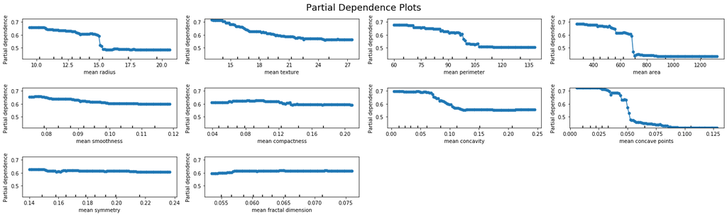

```python
n_cols = 4
n_rows = 10//n_cols + 1

fig = plt.figure(figsize=(20, 2*n_rows))
pdp(RF_clf, X_train, features=feature_names[:-1], feature_names=feature_names[:-1],
    n_cols=n_cols, fig=fig, line_kw={'marker': 'o', 'markeredgecolor': 'None'})

plt.suptitle('Partial Dependence Plots', fontsize=18)
plt.tight_layout(rect=[0, 0, 1, 0.97])
```

### Local Interpretability

#### LIME

- The explanation of individual datapoints is carried out with the help of Local interpretable model-agnostic explanations (LIME).
- Explanations are done with approximations of the black-box model with more interpretable models, usually GLMs

```python
i = np.random.randint(0, df_test.shape[0])
pred_i = RF_clf.predict_proba(df_test.iloc[[i], 0:-1])
print('Target: {:}'.format(pred_i[0, 1]))
df_test.iloc[[i], :]
```

```
Target: 0.9966666666666667
```

|  | mean radius | mean texture | mean perimeter | mean area | mean smoothness | mean compactness | mean concavity | mean concave points | mean symmetry | mean fractal dimension | target |
| --- | --- | --- | --- | --- | --- | --- | --- | --- | --- | --- | --- |
| 299 | 10.51 | 23.09 | 66.85 | 334.2 | 0.1015 | 0.06797 | 0.02495 | 0.01875 | 0.1695 | 0.06556 | 1 |

```python
explainer = LimeTabularExplainer(
    X_train, feature_names=feature_names, class_names=['target'],verbose=True)
exp = explainer.explain_instance(
    X_test[i], predict_fn=RF_clf.predict_proba, num_features=2, top_labels=1)
exp.show_in_notebook(show_table=True)
```

```
Intercept 0.5398441901730839
Prediction_local [0.77426873]
Right: 0.9966666666666667
```

#### SHAP

- Given a black-box model and one sample, SHAP attempts to decompose the effects of each feature on the differenc between the predicted value and the expected value of the model where the expectation is taken over the training examples (averaged training predictions).
- We can explain the predictions in either training or testing set but the explainer should be defined on the training set. In this section, we explain the training set.

```python
shap.initjs()
explainer = shap.KernelExplainer(RF_clf.predict_proba, shap.kmeans(X_train, 5))
n_explain = 200
shap_values = explainer.shap_values(X_train[:n_explain])
```

```python
explainer.expected_value
```

```
array([0.3190696, 0.6809304])
```

```python
i = 3
shap.force_plot(base_value=explainer.expected_value[1], shap_values=shap_values[1][i],
                features=X_train[i], feature_names=feature_names[:-1])
```

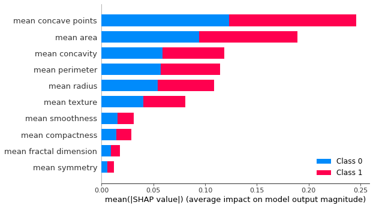

```python
shap.summary_plot(shap_values, X_train[:n_explain],feature_names)
```